# Summary of Results

#### We have trained three models with the following three types of [training data](https://quantumyilmaz.github.io/SPHS20/data_prep.html):

- $\textbf{LOB ,}$ [$\text{using only } \textit{Limit Order Book}$](https://quantumyilmaz.github.io/SPHS20/old_evals/evaluation_LOB.html)
- $\textbf{LIQ ,}$ [$\text{using only } \textit{Liquidity Measures}$](https://quantumyilmaz.github.io/SPHS20/old_evals/evaluation_LiqVars.html)
- $\textbf{LOB+LIQ ,}$ [$\text{using } \textit{Limit Order Book} \textbf{ and } \textit{Liquidity Measures } \text{together}$](https://quantumyilmaz.github.io/SPHS20/old_evals/evaluation_LOB_LiqVars.html)

```python
from IPython.display import HTML
def hide_code(): return HTML('''<script>code_show=true; function code_toggle() {if (code_show){$('div.input').hide();} else {$('div.input').show();}code_show = !code_show} $( document ).ready(code_toggle);</script><form action="javascript:code_toggle()"><input type="submit" value="Click here to toggle on/off the raw code."></form>''')
hide_code()
```

### Performance table

The training and validation performances of each model are shown below with $\textbf{Mean Squared Error (MSE)}$ and $\textbf{Mean Absolute Percentage Error (MAPE)}$ as the chosen performance criteria. Results obtained with linear regression $\textbf{(LinReg)}$ on prices are also added for comparison. Each value is rounded with a relative error less than 1%.

```python
import pandas as pd
import numpy as np
from utils.df_handler import get_significant_figures

indices = pd.MultiIndex.from_tuples([(i,k) for i in \
                ['mid price','bid price expectation','ask price expectation','bid price variance','ask price variance'] for k in ['train','val']])
errors = pd.DataFrame()
for name in ['LOB','LIQ','LOB+LIQ','LinReg']:
    with open('./eval/models/errors/' + f'{name}.npy', 'rb') as input:
        data = np.load(input,allow_pickle='TRUE')
        columns = pd.MultiIndex.from_tuples([(name,'MSE'),(name,'MAPE (%)')])
        errors = pd.concat([errors,pd.DataFrame(data,index=indices,columns=columns).transpose()],axis=0)
get_significant_figures(errors,2,0.01)
```

|  |  | mid price train | mid price val | bid price expectation train | bid price expectation val | ask price expectation train | ask price expectation val | bid price variance train | bid price variance val | ask price variance train | ask price variance val |
| --- | --- | --- | --- | --- | --- | --- | --- | --- | --- | --- | --- |
| LOB | MSE | 2.55•E-2 | 0.15•E-1 | 0.24•E-1 | 1.42•E-2 | 2.65•E-2 | 1.54•E-2 | 0.97•E-9 | 1.26•E-9 | 0.96•E-9 | 1.48•E-9 |
|  | MAPE (%) | 1.02 | 1.01 | 0.98 | 0.98 | 1.03 | 1.03 | 14.7 | 17.8 | 14.8 | 23 |
| LIQ | MSE | 0.49•E-1 | 1.73•E-1 | 0.49•E-1 | 1.75•E-1 | 0.5•E-1 | 1.78•E-1 | 0.98•E-9 | 1.25•E-9 | 0.96•E-9 | 1.48•E-9 |
|  | MAPE (%) | 1.78 | 3.27 | 1.76 | 3.3 | 1.77 | 3.32 | 14.6 | 17.6 | 14.6 | 22.6 |
| LOB+LIQ | MSE | 1.42•E-1 | 0.25 | 1.44•E-1 | 0.25 | 1.36•E-1 | 2.43•E-1 | 0.97•E-9 | 1.27•E-9 | 0.96•E-9 | 0.15•E-8 |
|  | MAPE (%) | 3.55 | 4.12 | 3.59 | 4.12 | 3.45 | 4.04 | 14.7 | 18 | 14.8 | 22.8 |
| LinReg | MSE | 1.56•E-1 | 1.43 | 1.56•E-1 | 1.43 | 1.56•E-1 | 1.43 | _ | _ | _ | _ |
|  | MAPE (%) | 3.23 | 11.1 | 3.24 | 11.2 | 3.23 | 11.1 | _ | _ | _ | _ |

##### Variance

Despite getting similar results for variances with all three of the models, $\textbf{LIQ}$ performs the best in terms of variance forecasting.

##### Price

The best price predictor is $\textbf{LOB}$, the model using Limit Order Book as training data.

##### Overall

The best result is obtained with $\textbf{LOB}$, whereas adding Liquidity Measures next to Limit Order Book data ($\textbf{LOB+LIQ}$) yields the worst performance.

### Performance Plots

Below we have plots illustrating the validation performances of the models.

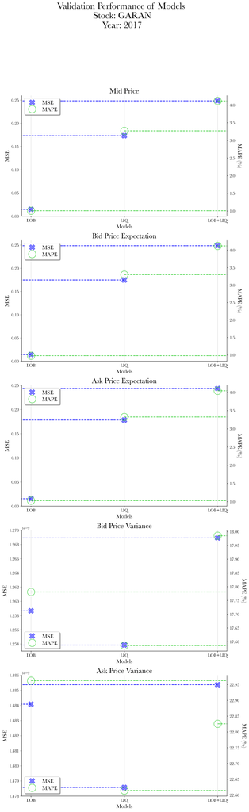

```python
from utils.plotter import plotter
args = [ #FIRST AXIS
        [ [['LOB','LIQ','LOB+LIQ'],errors[('mid price','val')].values[:-2:2],'X',dict(color='blue',label='MSE',markersize=15,alpha=0.5)]
         ,[errors[('mid price','val')].values[:-2:2],[0,1,2],[-1]*3,'blue','dashed']
         ,[-0.1,2.1],[0,0.26]
         ,{'plot':[['LOB','LIQ','LOB+LIQ'],errors[('mid price','val')].values[1:-2:2],'o'],'plot_specs':dict(marker='o',color='limegreen',label='MAPE',markersize=20,mfc='None'),'ylabel':dict(ylabel='MAPE (%)',fontsize=15,rotation=-90,labelpad=18),'tick_params':dict(axis='both',labelsize=12)}
         ,[dict(axis='both',labelsize=12)]
         ,['Models',dict(fontsize=15)], ['MSE',dict(fontsize=15)], ['Mid Price',dict(fontsize=20)]
         ,[dict(ncol=1,shadow=1,labelspacing=0.3,fontsize=15,loc='upper left')],[dict(b=True,axis='x',alpha=0.5)]
        ]
        ,#SECOND AXIS
        [ [['LOB','LIQ','LOB+LIQ'],errors[('bid price expectation','val')].values[:-2:2],'X',dict(color='blue',label='MSE',markersize=15,alpha=0.5)]
         ,[errors[('bid price expectation','val')].values[:-2:2],[0,1,2],[-1]*3,'blue','dashed']
         ,[-0.1,2.1],[0,0.26]
         ,{'plot':[['LOB','LIQ','LOB+LIQ'],errors[('bid price expectation','val')].values[1:-2:2],'o'],'plot_specs':dict(marker='o',color='limegreen',label='MAPE',markersize=20,mfc='None'),'ylabel':dict(ylabel='MAPE (%)',fontsize=15,rotation=-90,labelpad=18),'tick_params':dict(axis='both',labelsize=12)}
         ,[dict(axis='both',labelsize=12)]
         ,['Models',dict(fontsize=15)], ['MSE',dict(fontsize=15)], ['Bid Price Expectation',dict(fontsize=20)]
         ,[dict(ncol=1,shadow=1,labelspacing=0.3,fontsize=15,loc='upper left')],[dict(b=True,axis='x',alpha=0.5)]
        ]
        ,#THIRD AXIS
        [ [['LOB','LIQ','LOB+LIQ'],errors[('ask price expectation','val')].values[:-2:2],'X',dict(color='blue',label='MSE',markersize=15,alpha=0.5)]
         ,[errors[('ask price expectation','val')].values[:-2:2],[0,1,2],[-1]*3,'blue','dashed']
         ,[-0.1,2.1],[0,0.25]
         ,{'plot':[['LOB','LIQ','LOB+LIQ'],errors[('ask price expectation','val')].values[1:-2:2],'o'],'plot_specs':dict(marker='o',color='limegreen',label='MAPE',markersize=20,mfc='None'),'ylabel':dict(ylabel='MAPE (%)',fontsize=15,rotation=-90,labelpad=18),'tick_params':dict(axis='both',labelsize=12)}
         ,[dict(axis='both',labelsize=12)]
         ,['Models',dict(fontsize=15)], ['MSE',dict(fontsize=15)], ['Ask Price Expectation',dict(fontsize=20)]
         ,[dict(ncol=1,shadow=1,labelspacing=0.3,fontsize=15,loc='upper left')],[dict(b=True,axis='x',alpha=0.5)]
        ]
        ,#FOURTH AXIS
        [ [['LOB','LIQ','LOB+LIQ'],errors[('bid price variance','val')].values[:-2:2],'X',dict(color='blue',label='MSE',markersize=15,alpha=0.5)]
         ,[errors[('bid price variance','val')].values[:-2:2],[0,1,2],[-1]*3,'blue','dashed']
         ,[-0.1,2.1],[1.253e-9,1.27e-9]
         ,{'plot':[['LOB','LIQ','LOB+LIQ'],errors[('bid price variance','val')].values[1:-2:2],'o'],'plot_specs':dict(marker='o',color='limegreen',label='MAPE',markersize=20,mfc='None'),'ylabel':dict(ylabel='MAPE (%)',fontsize=15,rotation=-90,labelpad=18),'tick_params':dict(axis='both',labelsize=12)}
         ,[dict(axis='both',labelsize=12)]
         ,['Models',dict(fontsize=15)], ['MSE',dict(fontsize=15)], ['Bid Price Variance',dict(fontsize=20)]
         ,[dict(ncol=1,shadow=1,labelspacing=0.3,fontsize=15,loc='lower left')],[dict(b=True,axis='x',alpha=0.5)]
        ]
        ,#FIFTH AXIS
        [ [['LOB','LIQ','LOB+LIQ'],errors[('ask price variance','val')].values[:-2:2],'X',dict(color='blue',label='MSE',markersize=15,alpha=0.5)]
         ,[errors[('ask price variance','val')].values[:-2:2],[0,1,2],[-1]*3,'blue','dashed']
         ,[-0.1,2.1],[1.478e-9,1.486e-9]
         ,{'plot':[['LOB','LIQ','LOB+LIQ'],errors[('ask price variance','val')].values[1:-2:2],'o'],'plot_specs':dict(marker='o',color='limegreen',label='MAPE',markersize=20,mfc='None'),'ylabel':dict(ylabel='MAPE (%)',fontsize=15,rotation=-90,labelpad=18),'tick_params':dict(axis='both',labelsize=12)}
         ,[dict(axis='both',labelsize=12)]
         ,['Models',dict(fontsize=15)], ['MSE',dict(fontsize=15)], ['Ask Price Variance',dict(fontsize=20)]
         ,[dict(ncol=1,shadow=1,labelspacing=0.3,fontsize=15,loc='lower left')],[dict(b=True,axis='x',alpha=0.5)]
        ]
       ]

attrs = ['plot'
         ,'hlines'
         ,'set_xlim','set_ylim'
         ,'make_twiny'
         ,'tick_params'
         ,'set_xlabel','set_ylabel','set_title'
         ,'legend','grid']

plotter(args,attrs,fig_title='Validation Performance of Models\n Stock: GARAN\n Year: 2017',dpi=300, ncols=1,xpad=-10,ypad=5)
```